# Titanic Analysis

### Survival as a function of age:

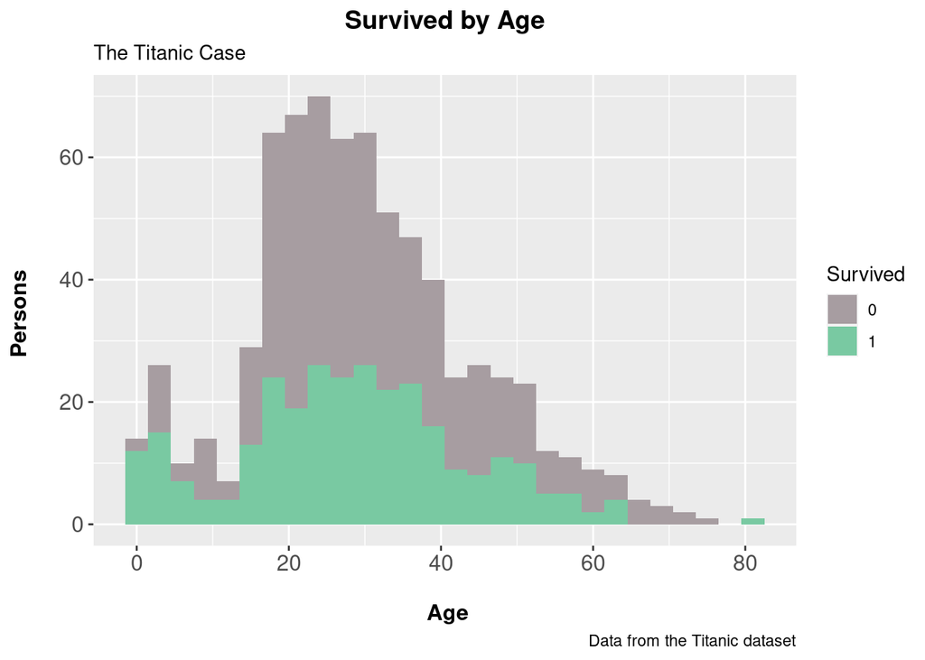

```r
ggplot(data = full1[!(is.na(full[1:LT,]$Age)),],aes(x=Age,fill=Survived))+geom_histogram(binwidth =3)+
  scale_fill_manual(values = c("#a79da1", "#79C9A2")) +   # color code for sex categories
  labs(title = "Survived by Age",
       subtitle = "The Titanic Case",
       caption = "Data from the Titanic dataset",
       x = "\n Age", y = "Persons \n")+
  theme(axis.text = element_text(size = 12),
        axis.title = element_text(size = 12, face = "bold"),
        plot.title = element_text(size = 14, hjust = 0.5, face = "bold"))
```

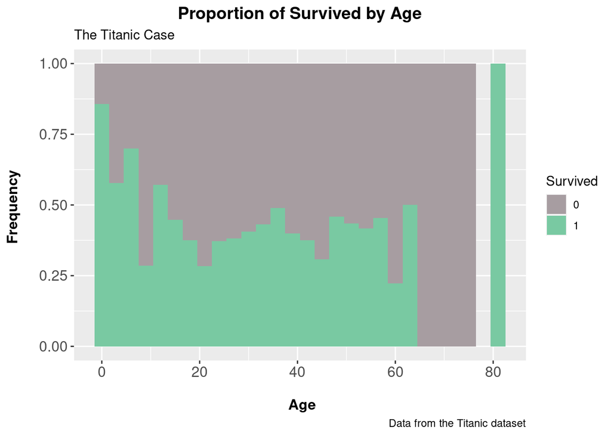

```r
ggplot(data = full1[!is.na(full[1:LT,]$Age),],aes(x=Age,fill=Survived))+geom_histogram(binwidth = 3,position="fill")+
  scale_fill_manual(values = c("#a79da1", "#79C9A2")) +
  labs(title = "Proportion of Survived by Age",
       subtitle = "The Titanic Case",
       caption = "Data from the Titanic dataset",
       x = "\n Age", y = "Frequency \n")+
  theme(axis.text = element_text(size = 12),
        axis.title = element_text(size = 12, face = "bold"),
        plot.title = element_text(size = 14, hjust = 0.5, face = "bold"))
```

```r
# Children (under 15) and old people (80+) had a better chance to survive.
```

### Additional research

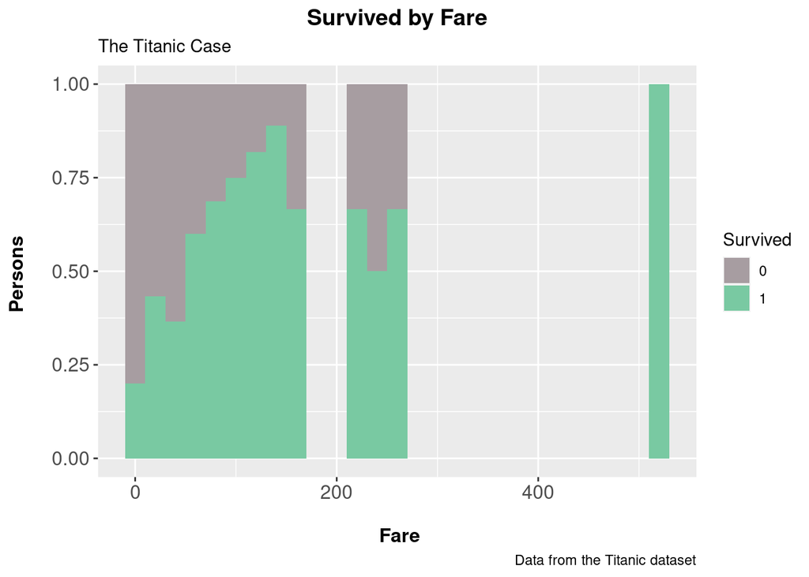

```r
# check the correlation of Fare versus Survivial
ggplot(data = full[1:LT,],aes(x=Fare,fill=Survived))+geom_histogram(binwidth =20, position="fill")+
  scale_fill_manual(values = c("#a79da1", "#79C9A2")) +   # color code for sex categories
  labs(title = "Survived by Fare",
       subtitle = "The Titanic Case",
       caption = "Data from the Titanic dataset",
       x = "\n Fare", y = "Persons \n")+
  theme(axis.text = element_text(size = 12),
        axis.title = element_text(size = 12, face = "bold"),
        plot.title = element_text(size = 14, hjust = 0.5, face = "bold"))
```

```r
full$Fare[is.na(full$Fare)] <- mean(full$Fare,na.rm=T)
sum(is.na(full$Fare))
```

```
## [1] 0
```

```r
# seems like bigger fare gave better chance to survive
```

```r
# check the missing values for Age
sum(is.na(full$Age))
```

```
## [1] 263
```

```r
# There are a lot of missing values in the Age attribute, put the mean instead of the missing values
full$Age[is.na(full$Age)] <- mean(full$Age,na.rm=T)
sum(is.na(full$Age))
```

```
## [1] 0
```

```r
# check the influence of a certain title of a passenger on the survival fact

full$Title <- gsub('(.*, )|(\\..*)', '', full$Name)
full$Title[full$Title == 'Mlle']<- 'Miss'
full$Title[full$Title == 'Ms']<- 'Miss'
full$Title[full$Title == 'Mme']<- 'Mrs'
full$Title[full$Title == 'Lady']<- 'Miss'
full$Title[full$Title == 'Dona']<- 'Miss'
officer<- c('Capt','Col','Don','Dr','Jonkheer','Major','Rev','Sir','the Countess')
full$Title[full$Title %in% officer]<-'Officer'

# convert Title into a factor
full$Title<- as.factor(full$Title)
```

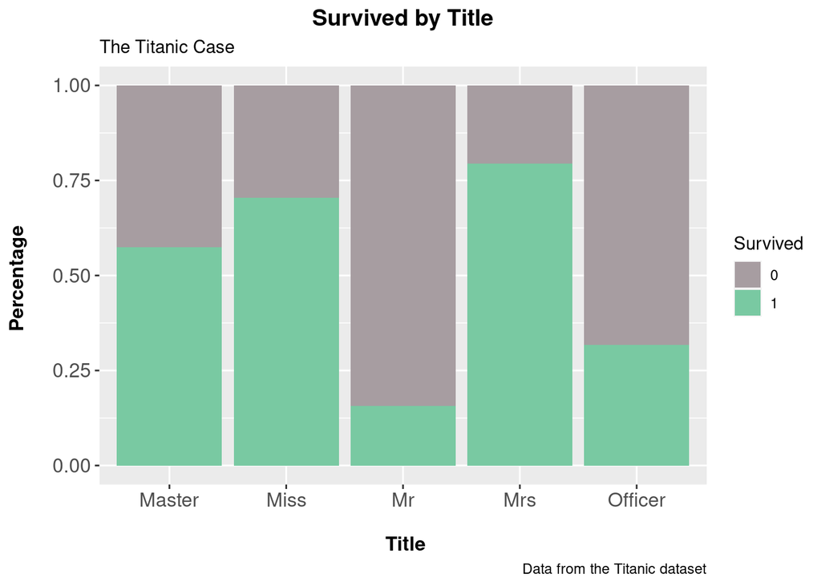

```r
# visualize the percentage of Survived vs Title
ggplot(data = full[1:LT,],aes(x=Title,fill=Survived))+geom_bar(position="fill")+
  scale_fill_manual(values = c("#a79da1", "#79C9A2")) +   # color code for sex categories
  labs(title = "Survived by Title",
       subtitle = "The Titanic Case",
       caption = "Data from the Titanic dataset",
       x = "\n Title", y = "Percentage \n")+
  theme(axis.text = element_text(size = 12),
        axis.title = element_text(size = 12, face = "bold"),
        plot.title = element_text(size = 14, hjust = 0.5, face = "bold"))
```

## Prediction

At this time point, let’s **predict the chance of survival as a function of the other attributes**. Let’s keep just the correlated features: **Pclass, Sex, Age, SibSp, Parch, Title and Fare.**

The *train* dataset will be divided into two sets: training set (*train1*) and test set (*train2*) to be able to estimate the error of the prediction.

```r
# The train set with the important features
train_im<- full[1:LT,c("Survived","Pclass","Sex","Age","Fare","SibSp","Parch","Title")]
ind<-sample(1:dim(train_im)[1],500) # Sample of 500 out of 891
train1<-train_im[ind,] # The train set of the model
train2<-train_im[-ind,] # The test set of the model
```

```r
# run a logistic regression
model <- glm(Survived ~.,family=binomial(link='logit'),data=train1)
summary(model)
```

```
##
## Call:
## glm(formula = Survived ~ ., family = binomial(link = "logit"),
##     data = train1)
##
## Deviance Residuals:
##     Min       1Q   Median       3Q      Max
## -2.1543  -0.5898  -0.4012   0.5993   2.3805
##
## Coefficients: (1 not defined because of singularities)
##               Estimate Std. Error z value Pr(>|z|)
## (Intercept)   4.269366   0.749001   5.700 1.20e-08 ***
## Pclass2      -1.447151   0.409483  -3.534 0.000409 ***
## Pclass3      -2.335663   0.385448  -6.060 1.36e-09 ***
## Sexmale      -0.627246   0.763383  -0.822 0.411267
## Age          -0.028955   0.011922  -2.429 0.015153 *
## Fare          0.003904   0.003053   1.279 0.200970
## SibSp        -0.482990   0.148924  -3.243 0.001182 **
## Parch        -0.174224   0.165781  -1.051 0.293292
## TitleMiss    -0.716673   0.459744  -1.559 0.119031
## TitleMr      -2.807591   0.730388  -3.844 0.000121 ***
## TitleMrs            NA         NA      NA       NA
## TitleOfficer -2.489366   0.954471  -2.608 0.009104 **
## ---
## Signif. codes:  0 '***' 0.001 '**' 0.01 '*' 0.05 '.' 0.1 ' ' 1
##
## (Dispersion parameter for binomial family taken to be 1)
##
##     Null deviance: 667.85  on 499  degrees of freedom
## Residual deviance: 429.49  on 489  degrees of freedom
## AIC: 451.49
##
## Number of Fisher Scoring iterations: 5
```

```r
# Let's look at the prediction of this model on the test set (train2):
pred.train <- predict(model,train2)
pred.train <- ifelse(pred.train > 0.5,1,0)
```

```r
# Mean of the true prediction
mean(pred.train==train2$Survived)
```

```
## [1] 0.8465473
```

```r
# make a summary table of the prediction model
t1<-table(pred.train,train2$Survived)
pander(t1)
```

|  | 0 | 1 |
| --- | --- | --- |
| **0** | 228 | 45 |
| **1** | 15 | 103 |

```r
# Presicion and recall of the model
presicion<- t1[1,1]/(sum(t1[1,]))
recall<- t1[1,1]/(sum(t1[,1]))
# get the precision and recall parameters
presicion
```

```
## [1] 0.8351648
```

```r
recall
```

```
## [1] 0.9382716
```

```r
# F1 score
F1<- 2*presicion*recall/(presicion+recall)
F1
```

```
## [1] 0.8837209
```

```r
# Let's run it on the test set:
test_im<-full[LT+1:1309,c("Pclass","Sex","Age","SibSp","Parch","Fare","Title")]
```

```r
#  make at the prediction of this model on the test set:
pred.test <- predict(model,test_im)[1:418]
pred.test <- ifelse(pred.test > 0.5,1,0)
```

```r
# put result into a data frame
res<- data.frame(test$PassengerId,pred.test)
names(res)<-c("PassengerId","Survived")
```

```r
# put the prediction result into a .csv file
write.csv(res,file="prediction.csv",row.names = F)
```

### Building a tree…

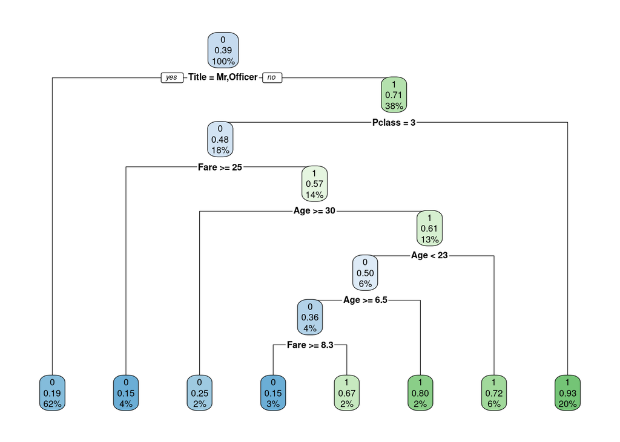

```r
# plant a tree and visualize it
model_dt<- rpart(Survived ~.,data=train1, method="class")
rpart.plot(model_dt)
```

```r
# make the prediction on the model
pred.train.dt <- predict(model_dt,train2,type = "class")
mean(pred.train.dt==train2$Survived)
```

```
## [1] 0.8618926
```

```r
t2<-table(pred.train.dt,train2$Survived)

presicion_dt<- t2[1,1]/(sum(t2[1,]))
recall_dt<- t2[1,1]/(sum(t2[,1]))
```

```r
# get the precision and recall
presicion_dt
```

```
## [1] 0.8539326
```

```r
recall_dt
```

```
## [1] 0.9382716
```

```r
# get the F1 score
F1_dt<- 2*presicion_dt*recall_dt/(presicion_dt+recall_dt)
F1_dt
```

```
## [1] 0.8941176
```

```r
# run this model on the test set:
pred.test.dt <- predict(model_dt,test_im,type="class")[1:418]
res_dt<- data.frame(test$PassengerId,pred.test.dt)
names(res_dt)<-c("PassengerId","Survived")
write.csv(res_dt,file="prediction_dt.csv",row.names = F)
```

```r
# make prediction on survival using a random forest
model_rf<-randomForest(Survived~.,data=train1)
```

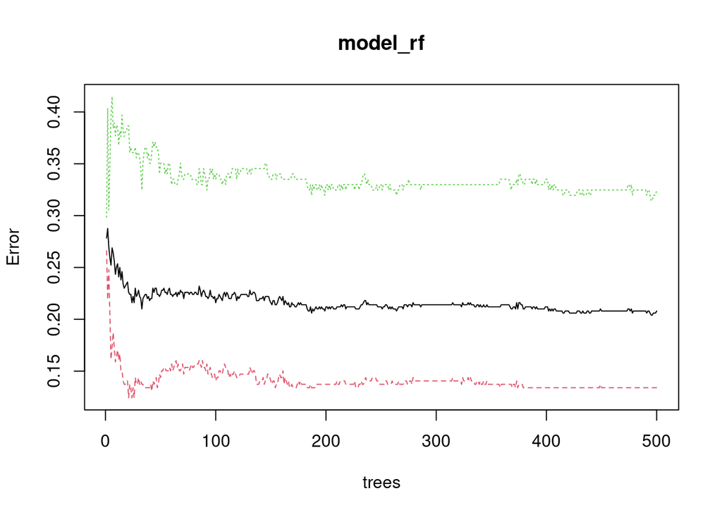

```r
# Let's look at the error
plot(model_rf)
```

```r
# make the prediction on the model
pred.train.rf <- predict(model_rf,train2)
mean(pred.train.rf==train2$Survived)
```

```
## [1] 0.8542199
```

```r
t1<-table(pred.train.rf,train2$Survived)
presicion<- t1[1,1]/(sum(t1[1,]))
recall<- t1[1,1]/(sum(t1[,1]))
presicion
```

```
## [1] 0.875
```

```r
recall
```

```
## [1] 0.8930041
```

```r
F1<- 2*presicion*recall/(presicion+recall)
F1
```

```
## [1] 0.8839104
```

```r
# Let's run this model on the test set:
pred.test.rf <- predict(model_rf,test_im)[1:418]
res_rf<- data.frame(test$PassengerId,pred.test.rf)
names(res_rf)<-c("PassengerId","Survived")
write.csv(res_rf,file="submission_rf.csv",row.names = F)
```

## Conclusion

### The mean of the right predictions:

- decision tree method: 0.77837
- random forest method: 0.77990
- logistic regression model: 0.7488

#### updated:

- 04/04/2023 - Made some cosmetics on some visuals (labels, theme…)

The colors picked up considering some wide-spread advice on visualization within the industry - to select the complementary colors for better readability.

Used this [resourse](https://www.color-hex.com/color/79c9a2) for the colour selection, actually.

- 09/04/2023 - Including pander library for certain table ra-shaping